# Reading the data

Luca Comba

2/8/2021

## Dataset files

I have deleted few rows that were explaining the variables and converted the xlxs files into csv.

#### 1. Meteorological Data for Fargo

Daily Observation Table for January 1 2000 to January 14 2021 Flag Definition Line:

- M - Missing;
- E - Estimated;
- N/A - Not Available

Variables:

- Station Name
- Latitude (deg)
- Longitude (deg)
- Elevation (ft)
- Year
- Month
- Day
- Avg Temp
- Avg Temp Flag
- Penman PET (mm)
- Rainfall (mm)
- Rainfall flag

```r
meteo_fargo <- read.csv("C:/Users/Luca/Desktop/SPRING2021/Statistical Research/CSV Cleaned/Meteorological Data for Fargo_cleaned.csv", encoding="UTF-8")

summary(meteo_fargo)
```

```
##  X.U.FEFF.Station.Name    Latitude      Longitude        Elevation
##  Fargo:7685            Min.   :46.9   Min.   :-96.81   Min.   :902
##                        1st Qu.:46.9   1st Qu.:-96.81   1st Qu.:902
##                        Median :46.9   Median :-96.81   Median :902
##                        Mean   :46.9   Mean   :-96.81   Mean   :902
##                        3rd Qu.:46.9   3rd Qu.:-96.81   3rd Qu.:902
##                        Max.   :46.9   Max.   :-96.81   Max.   :902
##
##       Year          Month             Day           Avg.Temp
##  Min.   :2000   Min.   : 1.000   Min.   : 1.00   Min.   :-33.020
##  1st Qu.:2005   1st Qu.: 4.000   1st Qu.: 8.00   1st Qu.: -4.217
##  Median :2010   Median : 7.000   Median :16.00   Median :  7.610
##  Mean   :2010   Mean   : 6.512   Mean   :15.72   Mean   :  6.072
##  3rd Qu.:2015   3rd Qu.:10.000   3rd Qu.:23.00   3rd Qu.: 17.950
##  Max.   :2021   Max.   :12.000   Max.   :31.00   Max.   : 32.595
##
##  Avg.Temp.Flag   Penman.PET     Penman.PET.Flag    Rainfall       Rainfall.Flag
##   :7644        Min.   : 0.000   Mode:logical    Min.   :  0.000    :4756
##  E:  41        1st Qu.: 0.864   NA's:7685       1st Qu.:  0.000   E: 125
##                Median : 2.565                   Median :  0.000   M:2804
##                Mean   : 3.384                   Mean   :  2.084
##                3rd Qu.: 5.613                   3rd Qu.:  0.305
##                Max.   :13.106                   Max.   :124.714
##                                                 NA's   :2804
```

```r
skim(meteo_fargo)
```

Data summary

| Name | meteo_fargo |
| --- | --- |
| Number of rows | 7685 |
| Number of columns | 13 |
| _______________________ |  |
| Column type frequency: |  |
| factor | 3 |
| logical | 1 |
| numeric | 9 |
| ________________________ |  |
| Group variables | None |

**Variable type: factor**

| skim_variable | n_missing | complete_rate | ordered | n_unique | top_counts |
| --- | --- | --- | --- | --- | --- |
| X.U.FEFF.Station.Name | 0 | 1 | FALSE | 1 | Far: 7685 |
| Avg.Temp.Flag | 0 | 1 | FALSE | 2 | emp: 7644, E: 41 |
| Rainfall.Flag | 0 | 1 | FALSE | 3 | emp: 4756, M: 2804, E: 125 |

**Variable type: logical**

| skim_variable | n_missing | complete_rate | mean | count |
| --- | --- | --- | --- | --- |
| Penman.PET.Flag | 7685 | 0 | NaN | : |

**Variable type: numeric**

| skim_variable | n_missing | complete_rate | mean | sd | p0 | p25 | p50 | p75 | p100 | hist |
| --- | --- | --- | --- | --- | --- | --- | --- | --- | --- | --- |
| Latitude | 0 | 1.00 | 46.90 | 0.00 | 46.90 | 46.90 | 46.90 | 46.90 | 46.90 | ▁▁▇▁▁ |
| Longitude | 0 | 1.00 | -96.81 | 0.00 | -96.81 | -96.81 | -96.81 | -96.81 | -96.81 | ▁▁▇▁▁ |
| Elevation | 0 | 1.00 | 902.00 | 0.00 | 902.00 | 902.00 | 902.00 | 902.00 | 902.00 | ▁▁▇▁▁ |
| Year | 0 | 1.00 | 2010.02 | 6.07 | 2000.00 | 2005.00 | 2010.00 | 2015.00 | 2021.00 | ▇▆▆▆▆ |
| Month | 0 | 1.00 | 6.51 | 3.45 | 1.00 | 4.00 | 7.00 | 10.00 | 12.00 | ▇▅▅▅▇ |
| Day | 0 | 1.00 | 15.72 | 8.80 | 1.00 | 8.00 | 16.00 | 23.00 | 31.00 | ▇▇▇▇▆ |
| Avg.Temp | 0 | 1.00 | 6.07 | 13.44 | -33.02 | -4.22 | 7.61 | 17.95 | 32.59 | ▁▅▇▇▅ |
| Penman.PET | 0 | 1.00 | 3.38 | 2.81 | 0.00 | 0.86 | 2.56 | 5.61 | 13.11 | ▇▃▃▁▁ |
| Rainfall | 2804 | 0.64 | 2.08 | 6.65 | 0.00 | 0.00 | 0.00 | 0.30 | 124.71 | ▇▁▁▁▁ |

We are replacing empty with the Not Available value

```r
meteo_fargo[meteo_fargo==""]<-NA
```

then we want to see what type of variable we have

```r
glimpse(meteo_fargo)
```

```
## Rows: 7,685
## Columns: 13
## $ X.U.FEFF.Station.Name <fct> Fargo, Fargo, Fargo, Fargo, Fargo, Fargo, Far...
## $ Latitude              <dbl> 46.897, 46.897, 46.897, 46.897, 46.897, 46.89...
## $ Longitude             <dbl> -96.812, -96.812, -96.812, -96.812, -96.812, ...
## $ Elevation             <int> 902, 902, 902, 902, 902, 902, 902, 902, 902, ...
## $ Year                  <int> 2000, 2000, 2000, 2000, 2000, 2000, 2000, 200...
## $ Month                 <int> 1, 1, 1, 1, 1, 1, 1, 1, 1, 1, 1, 1, 1, 1, 1, ...
## $ Day                   <int> 1, 2, 3, 4, 5, 6, 7, 8, 9, 10, 11, 12, 13, 14...
## $ Avg.Temp              <dbl> -7.929, -9.433, -14.645, -16.700, -6.256, -13...
## $ Avg.Temp.Flag         <fct> NA, NA, NA, NA, NA, NA, NA, NA, NA, NA, NA, N...
## $ Penman.PET            <dbl> 0.483, 0.432, 0.330, 0.483, 0.991, 0.483, 1.1...
## $ Penman.PET.Flag       <lgl> NA, NA, NA, NA, NA, NA, NA, NA, NA, NA, NA, N...
## $ Rainfall              <dbl> 0.000, 0.000, 0.000, 0.000, 0.000, 0.000, 0.0...
## $ Rainfall.Flag         <fct> NA, NA, NA, NA, NA, NA, NA, NA, NA, NA, NA, N...
```

We can see that the integers variables are *Elevation*, *Year*, *Month* and *Day*.

**Univariate Outliers** We will use boxplots and z-scores for finding outliers.

- Average Temperature outliers

```r
# Average Temperature
zScores_avg_temp_fargo <- (meteo_fargo$Avg.Temp - mean(meteo_fargo$Avg.Temp, na.rm = T)) / sd(meteo_fargo$Avg.Temp, na.rm = T)
sum(abs(zScores_avg_temp_fargo)> 3.29, na.rm = TRUE)
```

```
## [1] 0
```

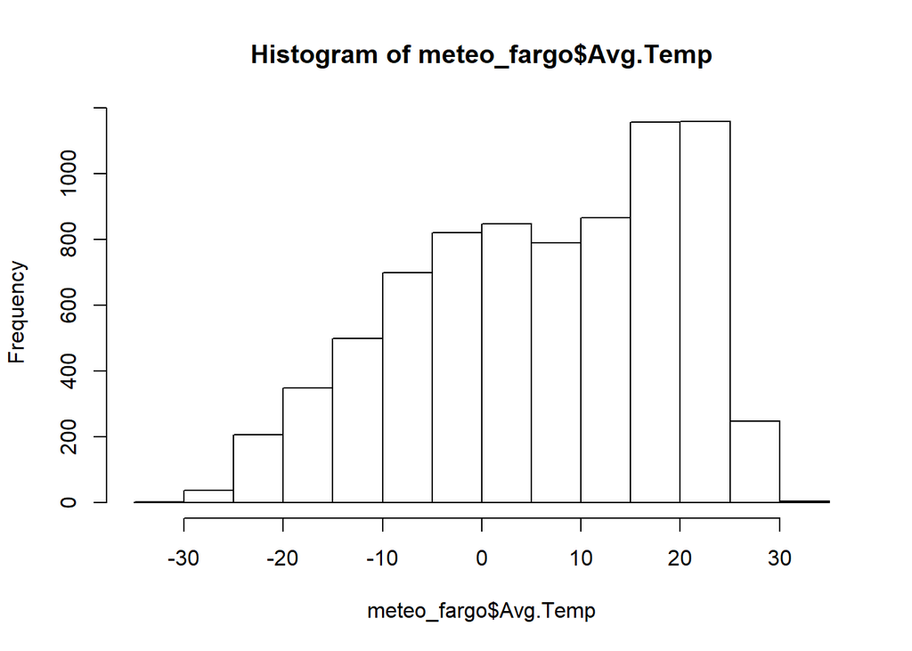

```r
hist(meteo_fargo$Avg.Temp)
```

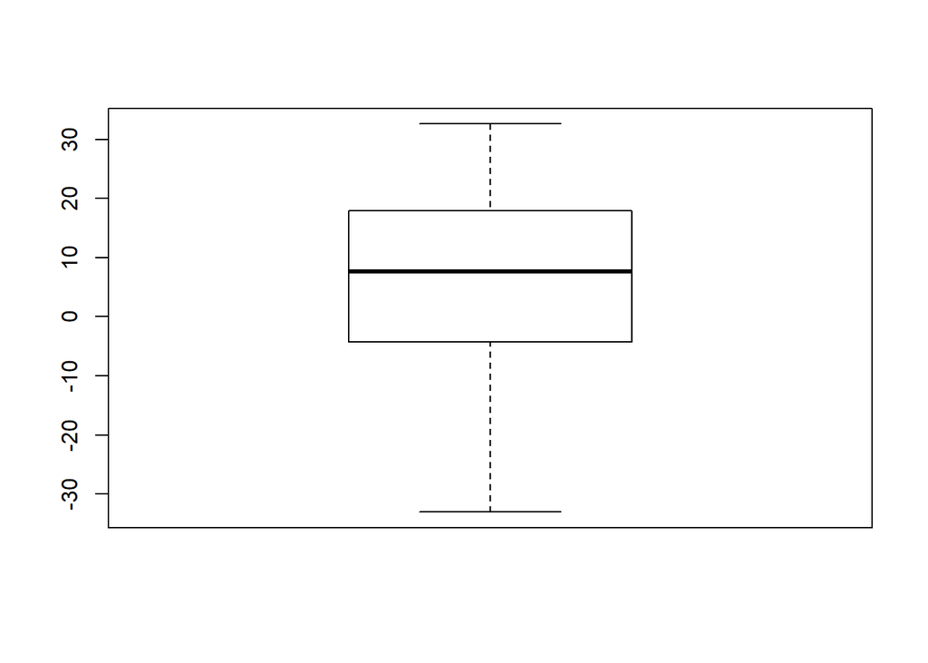

```r
boxplot(meteo_fargo$Avg.Temp)
```

- rainfall outliers

```r
# Rainfall
zScores_rainfall_fargo <- (meteo_fargo$Rainfall - mean(meteo_fargo$Rainfall, na.rm = T)) / sd(meteo_fargo$Rainfall, na.rm = T)
sum(abs(zScores_rainfall_fargo)> 3.29, na.rm = TRUE)
```

```
## [1] 96
```

With the zScore we have found that there are 96 outliers. We need to remember that out of 7685 cases we have 2804 `NA` because those data were missing and 125 were estimated.

```r
sum(is.na(meteo_fargo$Rainfall))
```

```
## [1] 2804
```

```r
sum(meteo_fargo["Rainfall.Flag"]=="E", na.rm = TRUE)
```

```
## [1] 125
```

```r
sum(meteo_fargo["Rainfall.Flag"]=="M", na.rm = TRUE)
```

```
## [1] 2804
```

The histogram is highly skewed right.

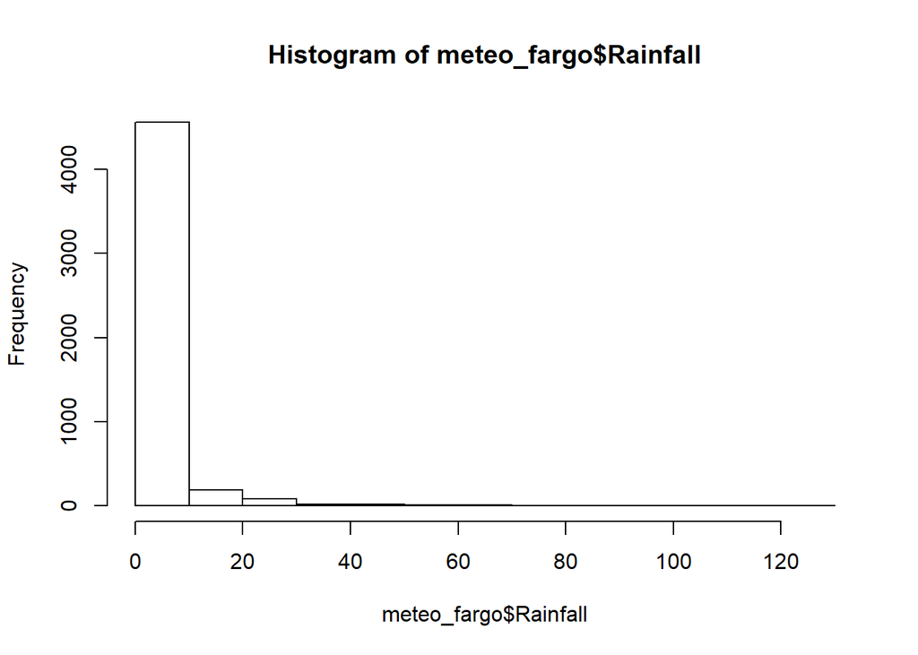

```r
hist(meteo_fargo$Rainfall)
```

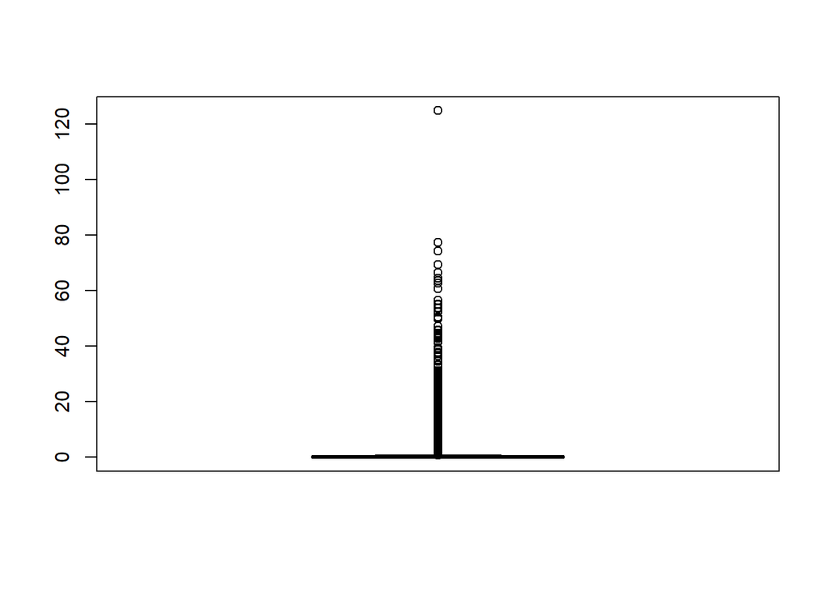

```r
boxplot(meteo_fargo$Rainfall)
```

- Penman PET (in mm)

```r
# Penman
zScores_penman_fargo <- (meteo_fargo$Penman.PET - mean(meteo_fargo$Penman.PET, na.rm = T)) / sd(meteo_fargo$Penman.PET, na.rm = T)
sum(abs(zScores_penman_fargo)> 3.29, na.rm = TRUE)
```

```
## [1] 7
```

For the variable Penman PET we have 7 outliers.

Also the histogram of Penman is skewed right.

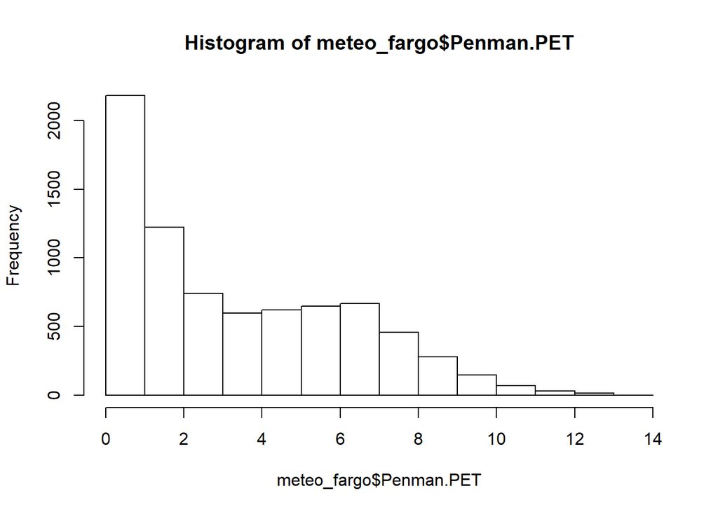

```r
hist(meteo_fargo$Penman.PET)
```

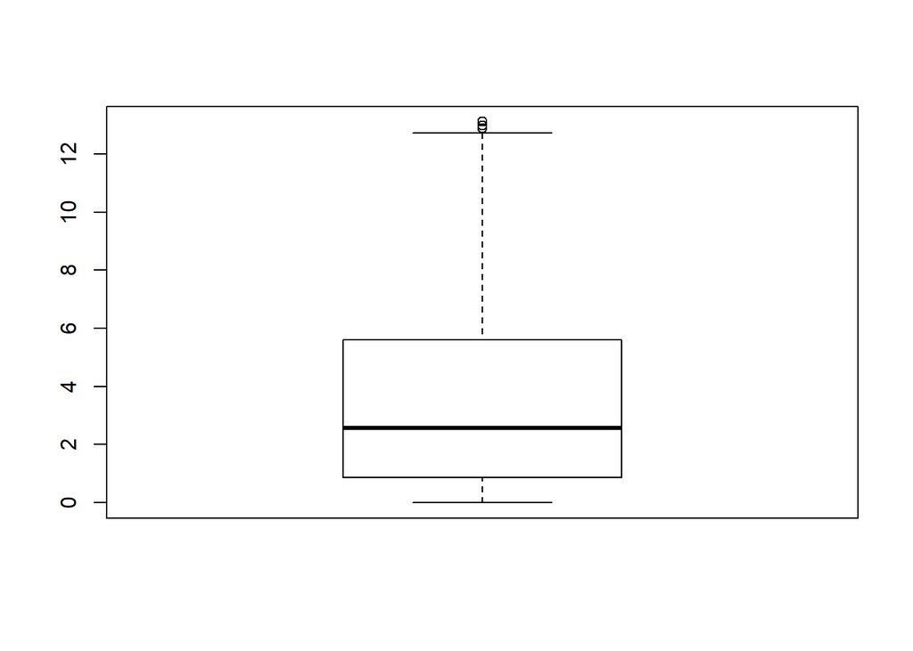

```r
boxplot(meteo_fargo$Penman.PET)
```

- Average Temperature with Rainfall

```r
#mahaDistance = mahalanobis(meteo_fargo$Avg.Temp, center = c(mean(meteo_fargo$Avg.Temp, na.rm = F), mean(meteo_fargo$Rainfall, na.rm = F)),cov = cov(cbind(meteo_fargo$Avg.Temp, meteo_fargo$Rainfall), use = "complete.obs"))

#mahaDistance
```

- Rainfall
- Penman.PET

**Skewness and kurtosis**

```r
require(moments)
# for average temperature
skewness(meteo_fargo$Avg.Temp)
```

```
## [1] -0.3733018
```

```r
kurtosis(meteo_fargo$Avg.Temp)
```

```
## [1] 2.134915
```

```r
pnorm(q =  (skewness(meteo_fargo$Avg.Temp) - 0) / sqrt(6 / length(meteo_fargo$Avg.Temp)), lower.tail = FALSE)
```

```
## [1] 1
```

```r
pnorm(q =  (kurtosis(meteo_fargo$Avg.Temp) - 0) / sqrt(24 / length(meteo_fargo$Avg.Temp)), lower.tail = FALSE)
```

```
## [1] 0
```

```r
# for rainfall
skewness(meteo_fargo$Rainfall, na.rm = T)
```

```
## [1] 5.974142
```

```r
kurtosis(meteo_fargo$Rainfall, na.rm = T)
```

```
## [1] 56.84336
```

```r
pnorm(q =  (skewness(meteo_fargo$Rainfall, na.rm = T) - 0) / sqrt(6 / length(meteo_fargo$Rainfall)), lower.tail = F)
```

```
## [1] 0
```

```r
pnorm(q =  (kurtosis(meteo_fargo$Rainfall, na.rm = T) - 0) / sqrt(24 / length(meteo_fargo$Rainfall)), lower.tail = F)
```

```
## [1] 0
```

```r
# for penman.PET
skewness(meteo_fargo$Penman.PET)
```

```
## [1] 0.7035884
```

```r
kurtosis(meteo_fargo$Penman.PET)
```

```
## [1] 2.484954
```

```r
pnorm(q =  (skewness(meteo_fargo$Penman.PET) - 0) / sqrt(6 / length(meteo_fargo$Penman.PET)), lower.tail = FALSE)
```

```
## [1] 3.272659e-140
```

```r
pnorm(q =  (kurtosis(meteo_fargo$Penman.PET) - 0) / sqrt(24 / length(meteo_fargo$Penman.PET)), lower.tail = FALSE)
```

```
## [1] 0
```

**Bivariate homoscedasticity** scatter plots are usually enough

**Bivariate linearity** use a qq-plot, it’s a bit cleaner than just an outright scatterplot - and be ready to transform anything that isn’t linear

**Multicollinearity & Singularity**

```r
corMat_fargo = cor(cbind(meteo_fargo$Avg.Temp, meteo_fargo$Rainfall, meteo_fargo$Penman.PET), use = "complete.obs")
corMat_fargo
```

```
##            [,1]        [,2]       [,3]
## [1,] 1.00000000  0.08413428  0.6841393
## [2,] 0.08413428  1.00000000 -0.1778377
## [3,] 0.68413932 -0.17783765  1.0000000
```

```r
eig = eigen(corMat_fargo)
```

There appears to be no multicollinearity or singularity because none of the correlations are above 0.9.

```r
eig = eigen(corMat_fargo)
sqrt(max(eig$values)/eig$values)
```

```
## [1] 1.000000 1.274706 2.508273
```

There appears to be no multicollinearity or singularity because none of the condition indices isabove 30

#### 2. Meteorological Data for Grand Forks

Daily Observation Table for January 1 2000 to January 14 2021 Flag Definition Line: M - Missing; E - Estimated; N/A - Not Available

Variables:

- Station Name
- Latitude (deg)
- Longitude (deg)
- Elevation (ft)
- Year
- Month
- Day
- Avg Temp
- Avg Temp Flag
- Penman PET (mm)
- Rainfall (mm)
- Rainfall flag

```r
meteo_grand <- read.csv("C:/Users/Luca/Desktop/SPRING2021/Statistical Research/CSV Cleaned/Meteorological Data for Grand Forks_cleaned.csv", encoding="UTF-8")

summary(meteo_grand)
```

```
##  X.U.FEFF.Station.Name    Latitude       Longitude        Elevation
##  Grand Forks:7685      Min.   :47.84   Min.   :-97.07   Min.   :846
##                        1st Qu.:47.84   1st Qu.:-97.07   1st Qu.:846
##                        Median :47.84   Median :-97.07   Median :846
##                        Mean   :47.84   Mean   :-97.07   Mean   :846
##                        3rd Qu.:47.84   3rd Qu.:-97.07   3rd Qu.:846
##                        Max.   :47.84   Max.   :-97.07   Max.   :846
##
##       Year          Month             Day           Avg.Temp
##  Min.   :2000   Min.   : 1.000   Min.   : 1.00   Min.   :-34.440
##  1st Qu.:2005   1st Qu.: 4.000   1st Qu.: 8.00   1st Qu.: -5.312
##  Median :2010   Median : 7.000   Median :16.00   Median :  6.692
##  Mean   :2010   Mean   : 6.512   Mean   :15.72   Mean   :  4.970
##  3rd Qu.:2015   3rd Qu.:10.000   3rd Qu.:23.00   3rd Qu.: 16.965
##  Max.   :2021   Max.   :12.000   Max.   :31.00   Max.   : 29.405
##
##  Avg.Temp.Flag   Penman.PET     Penman.PET.Flag    Rainfall       Rainfall.Flag
##   :7667        Min.   : 0.000   Mode:logical    Min.   :  0.000    :4409
##  E:  18        1st Qu.: 0.737   NA's:7685       1st Qu.:  0.000   E:  78
##                Median : 2.184                   Median :  0.000   M:3198
##                Mean   : 2.995                   Mean   :  2.097
##                3rd Qu.: 5.004                   3rd Qu.:  0.254
##                Max.   :13.310                   Max.   :104.140
##                                                 NA's   :3198
```

```r
skim(meteo_grand)
```

Data summary

| Name | meteo_grand |
| --- | --- |
| Number of rows | 7685 |
| Number of columns | 13 |
| _______________________ |  |
| Column type frequency: |  |
| factor | 3 |
| logical | 1 |
| numeric | 9 |
| ________________________ |  |
| Group variables | None |

**Variable type: factor**

| skim_variable | n_missing | complete_rate | ordered | n_unique | top_counts |
| --- | --- | --- | --- | --- | --- |
| X.U.FEFF.Station.Name | 0 | 1 | FALSE | 1 | Gra: 7685 |
| Avg.Temp.Flag | 0 | 1 | FALSE | 2 | emp: 7667, E: 18 |
| Rainfall.Flag | 0 | 1 | FALSE | 3 | emp: 4409, M: 3198, E: 78 |

**Variable type: logical**

| skim_variable | n_missing | complete_rate | mean | count |
| --- | --- | --- | --- | --- |
| Penman.PET.Flag | 7685 | 0 | NaN | : |

**Variable type: numeric**

| skim_variable | n_missing | complete_rate | mean | sd | p0 | p25 | p50 | p75 | p100 | hist |
| --- | --- | --- | --- | --- | --- | --- | --- | --- | --- | --- |
| Latitude | 0 | 1.00 | 47.84 | 0.00 | 47.84 | 47.84 | 47.84 | 47.84 | 47.84 | ▁▁▇▁▁ |
| Longitude | 0 | 1.00 | -97.07 | 0.00 | -97.07 | -97.07 | -97.07 | -97.07 | -97.07 | ▁▁▇▁▁ |
| Elevation | 0 | 1.00 | 846.00 | 0.00 | 846.00 | 846.00 | 846.00 | 846.00 | 846.00 | ▁▁▇▁▁ |
| Year | 0 | 1.00 | 2010.02 | 6.07 | 2000.00 | 2005.00 | 2010.00 | 2015.00 | 2021.00 | ▇▆▆▆▆ |
| Month | 0 | 1.00 | 6.51 | 3.45 | 1.00 | 4.00 | 7.00 | 10.00 | 12.00 | ▇▅▅▅▇ |
| Day | 0 | 1.00 | 15.72 | 8.80 | 1.00 | 8.00 | 16.00 | 23.00 | 31.00 | ▇▇▇▇▆ |
| Avg.Temp | 0 | 1.00 | 4.97 | 13.51 | -34.44 | -5.31 | 6.69 | 16.96 | 29.41 | ▁▅▇▇▇ |
| Penman.PET | 0 | 1.00 | 2.99 | 2.56 | 0.00 | 0.74 | 2.18 | 5.00 | 13.31 | ▇▃▂▁▁ |
| Rainfall | 3198 | 0.58 | 2.10 | 6.89 | 0.00 | 0.00 | 0.00 | 0.25 | 104.14 | ▇▁▁▁▁ |

#### 3. Snow Depth for Fargo

SnowDepth at -96.8120E and 46.8970N from October 1st 2003 to January 13th 2021

Variables:

- DateTime
- snow depth in mm

```r
snow_depth_fargo <- read.csv("C:/Users/Luca/Desktop/SPRING2021/Statistical Research/CSV Cleaned/Snow Depth for Fargo_cleaned.csv", encoding="UTF-8")

summary(snow_depth_fargo)
```

```
##  X.U.FEFF.DateTime
##  1/1/2004:   1
##  1/1/2005:   1
##  1/1/2006:   1
##  1/1/2007:   1
##  1/1/2008:   1
##  1/1/2009:   1
##  (Other) :6290
##  Snow.Depth..SNODAS..at..96.8120E.and.46.8970N.2003.10.01.to.2021.01.13
##  Min.   :  0.00
##  1st Qu.:  0.00
##  Median :  0.00
##  Mean   : 70.99
##  3rd Qu.: 67.00
##  Max.   :773.00
##
```

```r
skim(snow_depth_fargo)
```

Data summary

| Name | snow_depth_fargo |
| --- | --- |
| Number of rows | 6296 |
| Number of columns | 2 |
| _______________________ |  |
| Column type frequency: |  |
| factor | 1 |
| numeric | 1 |
| ________________________ |  |
| Group variables | None |

**Variable type: factor**

| skim_variable | n_missing | complete_rate | ordered | n_unique | top_counts |
| --- | --- | --- | --- | --- | --- |
| X.U.FEFF.DateTime | 0 | 1 | FALSE | 6296 | 1/1: 1, 1/1: 1, 1/1: 1, 1/1: 1 |

**Variable type: numeric**

| skim_variable | n_missing | complete_rate | mean | sd | p0 | p25 | p50 | p75 | p100 | hist |
| --- | --- | --- | --- | --- | --- | --- | --- | --- | --- | --- |
| Snow.Depth..SNODAS..at..96.8120E.and.46.8970N.2003.10.01.to.2021.01.13 | 0 | 1 | 70.99 | 140.09 | 0 | 0 | 0 | 67 | 773 | ▇▁▁▁▁ |

#### 4. Snow Depth for Grand Forks

SnowDepth at -97.0668E and 47.83630N from October 1st 2003 to January 13th 2021

Variables:

- DateTime
- snow depth in mm

```r
snow_depth_grand <- read.csv("C:/Users/Luca/Desktop/SPRING2021/Statistical Research/CSV Cleaned/Snow Depth from Grand Forks_cleaned.csv", encoding="UTF-8")

summary(meteo_grand)
```

```
##  X.U.FEFF.Station.Name    Latitude       Longitude        Elevation
##  Grand Forks:7685      Min.   :47.84   Min.   :-97.07   Min.   :846
##                        1st Qu.:47.84   1st Qu.:-97.07   1st Qu.:846
##                        Median :47.84   Median :-97.07   Median :846
##                        Mean   :47.84   Mean   :-97.07   Mean   :846
##                        3rd Qu.:47.84   3rd Qu.:-97.07   3rd Qu.:846
##                        Max.   :47.84   Max.   :-97.07   Max.   :846
##
##       Year          Month             Day           Avg.Temp
##  Min.   :2000   Min.   : 1.000   Min.   : 1.00   Min.   :-34.440
##  1st Qu.:2005   1st Qu.: 4.000   1st Qu.: 8.00   1st Qu.: -5.312
##  Median :2010   Median : 7.000   Median :16.00   Median :  6.692
##  Mean   :2010   Mean   : 6.512   Mean   :15.72   Mean   :  4.970
##  3rd Qu.:2015   3rd Qu.:10.000   3rd Qu.:23.00   3rd Qu.: 16.965
##  Max.   :2021   Max.   :12.000   Max.   :31.00   Max.   : 29.405
##
##  Avg.Temp.Flag   Penman.PET     Penman.PET.Flag    Rainfall       Rainfall.Flag
##   :7667        Min.   : 0.000   Mode:logical    Min.   :  0.000    :4409
##  E:  18        1st Qu.: 0.737   NA's:7685       1st Qu.:  0.000   E:  78
##                Median : 2.184                   Median :  0.000   M:3198
##                Mean   : 2.995                   Mean   :  2.097
##                3rd Qu.: 5.004                   3rd Qu.:  0.254
##                Max.   :13.310                   Max.   :104.140
##                                                 NA's   :3198
```

```r
skim(snow_depth_grand)
```

Data summary

| Name | snow_depth_grand |
| --- | --- |
| Number of rows | 6296 |
| Number of columns | 2 |
| _______________________ |  |
| Column type frequency: |  |
| factor | 1 |
| numeric | 1 |
| ________________________ |  |
| Group variables | None |

**Variable type: factor**

| skim_variable | n_missing | complete_rate | ordered | n_unique | top_counts |
| --- | --- | --- | --- | --- | --- |
| X.U.FEFF.DateTime | 0 | 1 | FALSE | 6296 | 1/1: 1, 1/1: 1, 1/1: 1, 1/1: 1 |

**Variable type: numeric**

| skim_variable | n_missing | complete_rate | mean | sd | p0 | p25 | p50 | p75 | p100 | hist |
| --- | --- | --- | --- | --- | --- | --- | --- | --- | --- | --- |
| Snow.Depth..SNODAS..at..97.0668E.and.47.8363N.2003.10.01.to.2021.01.13 | 0 | 1 | 69.75 | 128.36 | 0 | 0 | 0 | 73.25 | 651 | ▇▁▁▁▁ |

#### 5. Soil Temperatures

The data on this page have not been quality controlled. There are outliers and missing data

The soil temperatures are in degrees celsius

Data from 2014-10-02 1200 until 2021-01-15 1100

Variables:

- Station Time (CST)
- 5 cm
- 10 cm
- 20 cm
- 30 cm
- 40 cm
- 50 cm
- 60 cm
- 80 cm
- 100 cm
- 125 cm
- 150 cm
- 175 cm
- 200 cm
- 225 cm

```r
soil_temp<- read.csv("C:/Users/Luca/Desktop/SPRING2021/Statistical Research/CSV Cleaned/Soil Temperatures for Fargo and Grand Forks_cleaned.csv", encoding="UTF-8")

summary(soil_temp)
```

```
##     X.U.FEFF.Station           Time..CST.         X5.cm
##  Fargo      :55112   2014-10-02 1200:     2   Min.   :-17.650
##  Grand Forks:55263   2014-10-02 1300:     2   1st Qu.: -0.715
##                      2014-10-02 1400:     2   Median :  6.123
##                      2014-10-02 1500:     2   Mean   :  7.949
##                      2014-10-02 1600:     2   3rd Qu.: 17.100
##                      2014-10-02 1700:     2   Max.   :185.500
##                      (Other)        :110363   NA's   :190
##      X10.cm            X20.cm            X30.cm            X40.cm
##  Min.   :-14.410   Min.   :-11.600   Min.   : -8.990   Min.   : -7.031
##  1st Qu.: -0.423   1st Qu.: -0.181   1st Qu.:  0.010   1st Qu.:  0.337
##  Median :  6.345   Median :  6.384   Median :  6.386   Median :  6.527
##  Mean   :  7.892   Mean   :  7.862   Mean   :  7.854   Mean   :  7.855
##  3rd Qu.: 17.070   3rd Qu.: 16.720   3rd Qu.: 16.170   3rd Qu.: 15.660
##  Max.   : 58.470   Max.   :127.700   Max.   :149.800   Max.   :121.900
##  NA's   :190       NA's   :190       NA's   :190       NA's   :190
##      X50.cm            X60.cm            X80.cm           X100.cm
##  Min.   : -5.723   Min.   : -4.664   Min.   : -2.707   Min.   : -1.444
##  1st Qu.:  0.692   1st Qu.:  0.980   1st Qu.:  1.636   1st Qu.:  2.319
##  Median :  6.660   Median :  6.784   Median :  6.927   Median :  7.148
##  Mean   :  7.859   Mean   :  7.866   Mean   :  7.882   Mean   :  7.904
##  3rd Qu.: 15.290   3rd Qu.: 14.980   3rd Qu.: 14.210   3rd Qu.: 13.600
##  Max.   :163.000   Max.   :155.700   Max.   :102.500   Max.   :142.000
##  NA's   :190       NA's   :191       NA's   :191       NA's   :191
##     X125.cm           X150.cm           X175.cm           X200.cm
##  Min.   : -0.478   Min.   :  0.000   Min.   :  0.000   Min.   :  0.000
##  1st Qu.:  3.052   1st Qu.:  3.666   1st Qu.:  4.140   1st Qu.:  4.654
##  Median :  7.323   Median :  7.538   Median :  7.692   Median :  7.853
##  Mean   :  7.920   Mean   :  7.936   Mean   :  7.940   Mean   :  8.003
##  3rd Qu.: 12.890   3rd Qu.: 12.320   3rd Qu.: 11.820   3rd Qu.: 11.410
##  Max.   :158.300   Max.   :137.000   Max.   :120.300   Max.   :141.400
##  NA's   :191       NA's   :191       NA's   :189       NA's   :9572
##     X225.cm
##  Min.   :  0.000
##  1st Qu.:  5.027
##  Median :  7.917
##  Mean   :  8.000
##  3rd Qu.: 11.000
##  Max.   :111.700
##  NA's   :9573
```

```r
skim(soil_temp)
```

Data summary

| Name | soil_temp |
| --- | --- |
| Number of rows | 110375 |
| Number of columns | 16 |
| _______________________ |  |
| Column type frequency: |  |
| factor | 2 |
| numeric | 14 |
| ________________________ |  |
| Group variables | None |

**Variable type: factor**

| skim_variable | n_missing | complete_rate | ordered | n_unique | top_counts |
| --- | --- | --- | --- | --- | --- |
| X.U.FEFF.Station | 0 | 1 | FALSE | 2 | Gra: 55263, Far: 55112 |
| Time..CST. | 0 | 1 | FALSE | 55460 | 201: 2, 201: 2, 201: 2, 201: 2 |

**Variable type: numeric**

| skim_variable | n_missing | complete_rate | mean | sd | p0 | p25 | p50 | p75 | p100 | hist |
| --- | --- | --- | --- | --- | --- | --- | --- | --- | --- | --- |
| X5.cm | 190 | 1.00 | 7.95 | 10.48 | -17.65 | -0.72 | 6.12 | 17.10 | 185.50 | ▇▁▁▁▁ |
| X10.cm | 190 | 1.00 | 7.89 | 9.59 | -14.41 | -0.42 | 6.34 | 17.07 | 58.47 | ▇▇▇▁▁ |
| X20.cm | 190 | 1.00 | 7.86 | 8.84 | -11.60 | -0.18 | 6.38 | 16.72 | 127.70 | ▇▃▁▁▁ |
| X30.cm | 190 | 1.00 | 7.85 | 8.29 | -8.99 | 0.01 | 6.39 | 16.17 | 149.80 | ▇▁▁▁▁ |
| X40.cm | 190 | 1.00 | 7.86 | 7.82 | -7.03 | 0.34 | 6.53 | 15.66 | 121.90 | ▇▁▁▁▁ |
| X50.cm | 190 | 1.00 | 7.86 | 7.46 | -5.72 | 0.69 | 6.66 | 15.29 | 163.00 | ▇▁▁▁▁ |
| X60.cm | 191 | 1.00 | 7.87 | 7.10 | -4.66 | 0.98 | 6.78 | 14.98 | 155.70 | ▇▁▁▁▁ |
| X80.cm | 191 | 1.00 | 7.88 | 6.44 | -2.71 | 1.64 | 6.93 | 14.21 | 102.50 | ▇▁▁▁▁ |
| X100.cm | 191 | 1.00 | 7.90 | 5.85 | -1.44 | 2.32 | 7.15 | 13.60 | 142.00 | ▇▁▁▁▁ |
| X125.cm | 191 | 1.00 | 7.92 | 5.19 | -0.48 | 3.05 | 7.32 | 12.89 | 158.30 | ▇▁▁▁▁ |
| X150.cm | 191 | 1.00 | 7.94 | 4.61 | 0.00 | 3.67 | 7.54 | 12.32 | 137.00 | ▇▁▁▁▁ |
| X175.cm | 189 | 1.00 | 7.94 | 4.11 | 0.00 | 4.14 | 7.69 | 11.82 | 120.30 | ▇▁▁▁▁ |
| X200.cm | 9572 | 0.91 | 8.00 | 3.69 | 0.00 | 4.65 | 7.85 | 11.41 | 141.40 | ▇▁▁▁▁ |
| X225.cm | 9573 | 0.91 | 8.00 | 3.28 | 0.00 | 5.03 | 7.92 | 11.00 | 111.70 | ▇▁▁▁▁ |

#### 6. Streamflow for Fargo

Some of the data that you have obtained from this U.S. Geological Survey database may not have received Director’s approval. Any such data values are qualified as provisional and are subject to revision. Provisional data are released on the condition that neither the USGS nor the United States Government may be held liable for any damages resulting from its use.

Additional info: https://help.waterdata.usgs.gov/policies/provisional-data-statement

File-format description: https://help.waterdata.usgs.gov/faq/about-tab-delimited-output Automated-retrieval info: https://help.waterdata.usgs.gov/faq/automated-retrievals

Contact: gs-w_support_nwisweb@usgs.gov retrieved: 2021-01-15 13:35:27 EST (caww01)

Data for the following 1 site(s) are contained in this file USGS 05054000 RED RIVER OF THE NORTH AT FARGO, ND ———————————————————————————–

Data provided for site 05054000 TS parameter statistic Description 90936 00060 00003 Discharge, cubic feet per second (Mean)

Data-values qualification code: A Approved for publication – Processing and review completed. P Provisional data subject to revision. e Value has been estimated.

Variables: - agency_cd - site_no datetime - 90936_00060_00003 - 90936_00060_00003_cd

```r
streamflow_fargo<- read.csv("C:/Users/Luca/Desktop/SPRING2021/Statistical Research/CSV Cleaned/Streamflow for Fargo from USGS_cleaned.csv", encoding="UTF-8")

summary(streamflow_fargo)
```

```
##  X.U.FEFF.agency_cd    site_no                 datetime      X90936_00060_00003
##      :360918        Min.   :5054000                :360918          :360932
##  USGS:  7682        1st Qu.:5054000   1/1/2000 0:00:     1   Ice    :   154
##                     Median :5054000   1/1/2001 0:00:     1   1240   :    40
##                     Mean   :5054000   1/1/2002 0:00:     1   1150   :    28
##                     3rd Qu.:5054000   1/1/2003 0:00:     1   1020   :    27
##                     Max.   :5054000   1/1/2004 0:00:     1   1170   :    27
##                     NA's   :360918    (Other)      :  7677   (Other):  7392
##  X90936_00060_00003_cd
##     :360932
##  A  :  4901
##  A:e:  2378
##  P  :   385
##  P:e:     4
##
##
```

```r
skim(streamflow_fargo)
```

Data summary

| Name | streamflow_fargo |
| --- | --- |
| Number of rows | 368600 |
| Number of columns | 5 |
| _______________________ |  |
| Column type frequency: |  |
| factor | 4 |
| numeric | 1 |
| ________________________ |  |
| Group variables | None |

**Variable type: factor**

| skim_variable | n_missing | complete_rate | ordered | n_unique | top_counts |
| --- | --- | --- | --- | --- | --- |
| X.U.FEFF.agency_cd | 0 | 1 | FALSE | 2 | emp: 360918, USG: 7682 |
| datetime | 0 | 1 | FALSE | 7683 | emp: 360918, 1/1: 1, 1/1: 1, 1/1: 1 |
| X90936_00060_00003 | 0 | 1 | FALSE | 1589 | emp: 360932, Ice: 154, 124: 40, 115: 28 |
| X90936_00060_00003_cd | 0 | 1 | FALSE | 5 | emp: 360932, A: 4901, A:e: 2378, P: 385 |

**Variable type: numeric**

| skim_variable | n_missing | complete_rate | mean | sd | p0 | p25 | p50 | p75 | p100 | hist |
| --- | --- | --- | --- | --- | --- | --- | --- | --- | --- | --- |
| site_no | 360918 | 0.02 | 5054000 | 0 | 5054000 | 5054000 | 5054000 | 5054000 | 5054000 | ▁▁▇▁▁ |

#### 7. Streamflow for Grand Forks

Some of the data that you have obtained from this U.S. Geological Survey database may not have received Director’s approval. Any such data values are qualified as provisional and are subject to revision. Provisional data are released on the condition that neither the USGS nor the United States Government may be held liable for any damages resulting from its use.

Additional info: https://help.waterdata.usgs.gov/policies/provisional-data-statement

File-format description: https://help.waterdata.usgs.gov/faq/about-tab-delimited-output Automated-retrieval info: https://help.waterdata.usgs.gov/faq/automated-retrievals

Contact: gs-w_support_nwisweb@usgs.gov retrieved: 2021-01-15 13:35:27 EST (caww01)

Data-values qualification code: A Approved for publication – Processing and review completed. P Provisional data subject to revision. e Value has been estimated.

Variables: - agency_cd - site_no datetime - 90936_00060_00003 - 90936_00060_00003_cd

```r
streamflow_grand<- read.csv("C:/Users/Luca/Desktop/SPRING2021/Statistical Research/CSV Cleaned/Streamflow for Grand Forks from USGS_cleaned.csv", encoding="UTF-8")

summary(streamflow_grand)
```

```
##  X.U.FEFF.agency_cd    site_no                 datetime      X91262_00060_00003
##      :482803        Min.   :5082500                :482803          :482808
##  USGS:  7685        1st Qu.:5082500   1/1/2000     :     1   Ice    :   179
##                     Median :5082500   1/1/2001 0:00:     1   2500   :    45
##                     Mean   :5082500   1/1/2002 0:00:     1   2600   :    36
##                     3rd Qu.:5082500   1/1/2003 0:00:     1   2450   :    35
##                     Max.   :5082500   1/1/2004 0:00:     1   1060   :    32
##                     NA's   :482803    (Other)      :  7680   (Other):  7353
##  X91262_00060_00003_cd
##     :482808
##  A  :  4770
##  A:e:  2492
##  P  :   418
##
##
##
```

```r
skim(streamflow_grand)
```

Data summary

| Name | streamflow_grand |
| --- | --- |
| Number of rows | 490488 |
| Number of columns | 5 |
| _______________________ |  |
| Column type frequency: |  |
| factor | 4 |
| numeric | 1 |
| ________________________ |  |
| Group variables | None |

**Variable type: factor**

| skim_variable | n_missing | complete_rate | ordered | n_unique | top_counts |
| --- | --- | --- | --- | --- | --- |
| X.U.FEFF.agency_cd | 0 | 1 | FALSE | 2 | emp: 482803, USG: 7685 |
| datetime | 0 | 1 | FALSE | 7686 | emp: 482803, 1/1: 1, 1/1: 1, 1/1: 1 |
| X91262_00060_00003 | 0 | 1 | FALSE | 1588 | emp: 482808, Ice: 179, 250: 45, 260: 36 |
| X91262_00060_00003_cd | 0 | 1 | FALSE | 4 | emp: 482808, A: 4770, A:e: 2492, P: 418 |

**Variable type: numeric**

| skim_variable | n_missing | complete_rate | mean | sd | p0 | p25 | p50 | p75 | p100 | hist |
| --- | --- | --- | --- | --- | --- | --- | --- | --- | --- | --- |
| site_no | 482803 | 0.02 | 5082500 | 0 | 5082500 | 5082500 | 5082500 | 5082500 | 5082500 | ▁▁▇▁▁ |